# Midterm 1 W24

Key

2024-02-08

## Instructions

Answer the following questions and complete the exercises in RMarkdown. Please embed all of your code and push your final work to your repository. Your code must be organized, clean, and run free from errors. Remember, you must remove the `#` for any included code chunks to run. Be sure to add your name to the author header above.

Your code must knit in order to be considered. If you are stuck and cannot answer a question, then comment out your code and knit the document. You may use your notes, labs, and homework to help you complete this exam. Do not use any other resources- including AI assistance.

Don’t forget to answer any questions that are asked in the prompt!

Be sure to push your completed midterm to your repository. This exam is worth 30 points.

## Background

In the data folder, you will find data related to a study on wolf mortality collected by the National Park Service. You should start by reading the `README_NPSwolfdata.pdf` file. This will provide an abstract of the study and an explanation of variables.

The data are from: Cassidy, Kira et al. (2022). Gray wolf packs and human-caused wolf mortality. [Dryad](https://doi.org/10.5061/dryad.mkkwh713f).

## Load the libraries

```r
library("tidyverse")
library("janitor")
```

## Load the wolves data

In these data, the authors used `NULL` to represent missing values. I am correcting this for you below and using `janitor` to clean the column names.

```r
wolves <- read.csv("data/NPS_wolfmortalitydata.csv", na = c("NULL")) %>% clean_names()
```

## Questions

Problem 1. (1 point) Let’s start with some data exploration. What are the variable (column) names?

```r
names(wolves)
```

```
##  [1] "park"         "biolyr"       "pack"         "packcode"     "packsize_aug"
##  [6] "mort_yn"      "mort_all"     "mort_lead"    "mort_nonlead" "reprody1"
## [11] "persisty1"
```

Problem 2. (1 point) Use the function of your choice to summarize the data and get an idea of its structure.

```r
str(wolves)
```

```
## 'data.frame':    864 obs. of  11 variables:
##  $ park        : chr  "DENA" "DENA" "DENA" "DENA" ...
##  $ biolyr      : int  1996 1991 2017 1996 1992 1994 2007 2007 1995 2003 ...
##  $ pack        : chr  "McKinley River1" "Birch Creek N" "Eagle Gorge" "East Fork" ...
##  $ packcode    : int  89 58 71 72 74 77 101 108 109 53 ...
##  $ packsize_aug: num  12 5 8 13 7 6 10 NA 9 8 ...
##  $ mort_yn     : int  1 1 1 1 1 1 1 1 1 1 ...
##  $ mort_all    : int  4 2 2 2 2 2 2 2 2 1 ...
##  $ mort_lead   : int  2 2 0 0 0 0 1 2 1 1 ...
##  $ mort_nonlead: int  2 0 2 2 2 2 1 0 1 0 ...
##  $ reprody1    : int  0 0 NA 1 NA 0 0 1 0 1 ...
##  $ persisty1   : int  0 0 1 1 1 1 0 1 0 1 ...
```

Problem 3. (3 points) Which parks/ reserves are represented in the data? Don’t just use the abstract, pull this information from the data.

Denali National Park and Preserve (DENA), Grand Teton National Park (GNTP), Voyageurs National Park (VNP), Yellowstone National Park (YNP), and Yukon-Charley Rivers National Preserve (YUCH).

```r
wolves %>% distinct(park)
```

```
##   park
## 1 DENA
## 2 GNTP
## 3  VNP
## 4  YNP
## 5 YUCH
```

Problem 4. (4 points) Which park has the largest number of wolf packs?

```r
wolves %>%
  group_by(park) %>%
  summarize(packs = n_distinct(pack)) %>%
  arrange(desc(packs))
```

```
## # A tibble: 5 × 2
##   park  packs
##   <chr> <int>
## 1 DENA     69
## 2 YNP      46
## 3 YUCH     36
## 4 VNP      22
## 5 GNTP     12
```

Problem 5. (4 points) Which park has the highest total number of human-caused mortalities?

```r
wolves %>%
  group_by(park) %>%
  summarize(deaths = sum(mort_all)) %>%
  arrange(desc(deaths))
```

```
## # A tibble: 5 × 2
##   park  deaths
##   <chr>  <int>
## 1 YUCH     136
## 2 YNP       72
## 3 DENA      64
## 4 GNTP      38
## 5 VNP       11
```

The wolves in [Yellowstone National Park](https://www.nps.gov/yell/learn/nature/wolf-restoration.htm) are an incredible conservation success story. Let’s focus our attention on this park.

Problem 6. (2 points) Create a new object “ynp” that only includes the data from Yellowstone National Park.

```r
ynp <- wolves %>% filter(park == "YNP")
```

Problem 7. (3 points) Among the Yellowstone wolf packs, the [Druid Peak Pack](https://www.pbs.org/wnet/nature/in-the-valley-of-the-wolves-the-druid-wolf-pack-story/209/) is one of most famous. What was the average pack size of this pack for the years represented in the data?

```r
druids <- ynp %>% filter(pack=="druid")
```

```r
mean(druids$packsize_aug)
```

```
## [1] 13.93333
```

```r
ynp %>%
  filter(pack=="druid") %>%
  summarize(mean_packsize = mean(packsize_aug))
```

```
##   mean_packsize
## 1      13.93333
```

Problem 8. (4 points) Pack dynamics can be hard to predict- even for strong packs like the Druid Peak pack. At which year did the Druid Peak pack have the largest pack size? What do you think happened in 2010?

2001 was the largest pack size. In 2010 the pack had no reproduction and dissolved.

```r
wolves %>%
  filter(pack=="druid") %>%
  select(biolyr, packsize_aug) %>%
  arrange(biolyr)
```

```
##    biolyr packsize_aug
## 1    1996            5
## 2    1997            5
## 3    1998            8
## 4    1999            9
## 5    2000           27
## 6    2001           37
## 7    2002           16
## 8    2003           18
## 9    2004           13
## 10   2005            5
## 11   2006           15
## 12   2007           18
## 13   2008           21
## 14   2009           12
## 15   2010            0
```

Problem 9. (5 points) Among the YNP wolf packs, which one has had the highest overall persistence `persisty1` for the years represented in the data? Look this pack up online and tell me what is unique about its behavior- specifically, what prey animals does this pack specialize on?

[Mollies Pack](https://www.yellowstonewolf.org/yellowstones_wolves.php?pack_id=6). They are the only pack known to hunt bison.

```r
ynp %>%
  group_by(pack) %>%
  summarize(persistence = sum(persisty1, na.rm=T)) %>%
  arrange(desc(persistence))
```

```
## # A tibble: 46 × 2
##    pack        persistence
##    <chr>             <int>
##  1 mollies              26
##  2 cougar               20
##  3 yelldelta            18
##  4 druid                13
##  5 leopold              12
##  6 agate                10
##  7 8mile                 9
##  8 canyon                9
##  9 gibbon/mary           9
## 10 nezperce              9
## # ℹ 36 more rows
```

Problem 10. (3 points) Perform one analysis or exploration of your choice on the `wolves` data. Your answer needs to include at least two lines of code and not be a summary function.

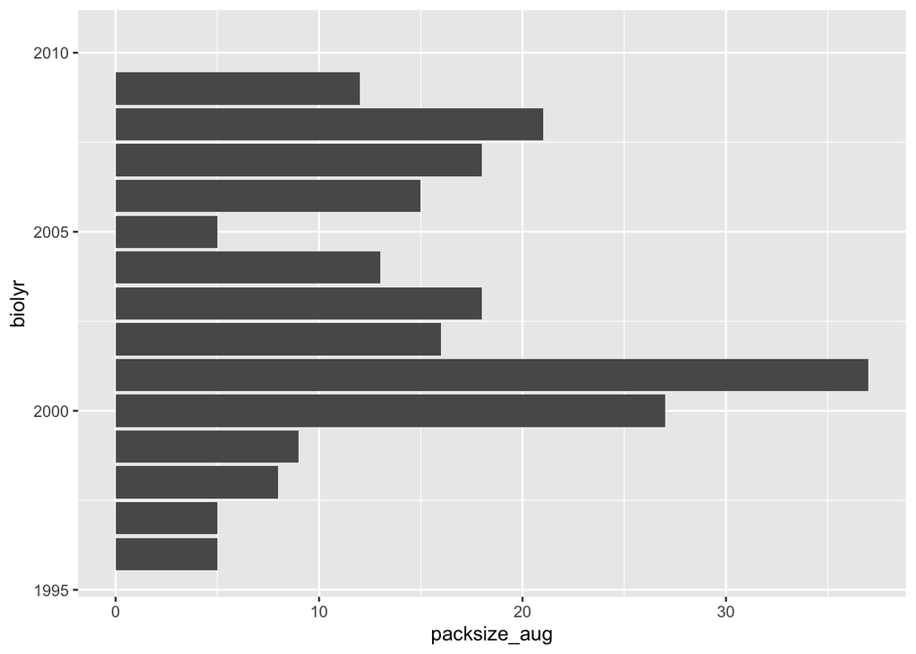

```r
ynp %>%
  filter(pack=="druid") %>%
  ggplot(aes(x=biolyr, y=packsize_aug)) +
  geom_col()+
  coord_flip()
```